# KRAS G13 Synthetic Lethality

Joshua H. Cook

June 11, 2019

# 1 Purpose

The goal of this analysis is to identify synthetic lethal interactions with *KRAS* G13D mutations.

# 2 Data

The data is from the genome-wide CRISPR-Cas9 loss-of-function screen named “Achilles” from the [DepMap Project](https://depmap.org/portal/). This data was downloaded, cleaned, and made available in the [‘tidy_Achilles’ GitHub repository](https://github.com/jhrcook/tidy_Achilles).

## 2.1 The cell lines

The following plot shows the number of cell lines in CCLE with either a *KRAS* or *NRAS* mutation (only showing alleles found in at least two cell lines of a disease).

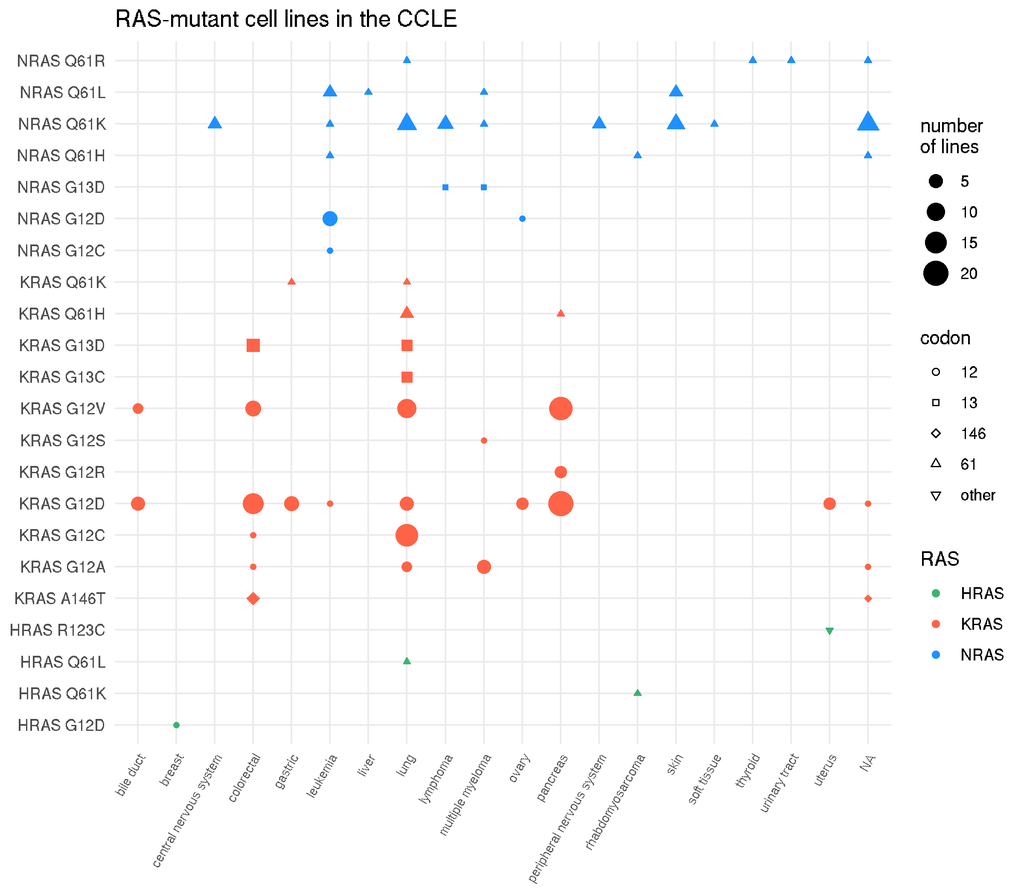

However, the DepMap has yet to screen all of the CCLE cell lines. The following only includes the cell lines used in Achilles.

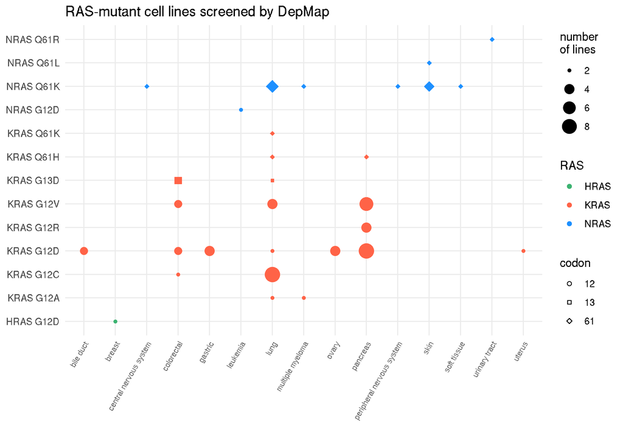

```r
ids_screened <- readRDS(file.path("data", "Achilles_gene_effect.tib")) %>%
    pull(dep_map_id) %>%
    unlist() %>%
    unique()
```

As of the 2019Q2 release, there are 563 screened cell lines. The most frequent allele is *KRAS* G12D, and the organs with the most frequent *KRAS* mutants are colorectal, lung, and pancreas. The following table shows the number of cell lines with each *KRAS* allele.

```r
readRDS(file.path("data", "ras_mutants_info.tib")) %>%
    filter(dep_map_id %in% !!ids_screened & ras == "KRAS") %>%
    count(ras_allele, disease) %>%
    filter(n >= 2) %>%
    mutate(disease = str_to_title(str_replace_all(disease, "_", " ")),
           ras_allele = str_replace_all(ras_allele, "_", " ")) %>%
    arrange(disease, desc(n)) %>%
    dplyr::rename(`RAS allele` = "ras_allele",
                  `Origin of cell line` = "disease",
                  `num. of cell lines` = "n")
```

| RAS allele | Origin of cell line | num. of cell lines |
| --- | --- | --- |
| KRAS G12D | Bile Duct | 3 |
| KRAS G12D | Colorectal | 3 |
| KRAS G12V | Colorectal | 3 |
| KRAS G13D | Colorectal | 3 |
| KRAS G12C | Colorectal | 2 |
| KRAS G12D | Gastric | 4 |
| KRAS G12C | Lung | 9 |
| KRAS G12V | Lung | 4 |
| KRAS G12A | Lung | 2 |
| KRAS G12D | Lung | 2 |

[output cut: 10 more lines]

## 2.2 The dependency scores

Below are the distributions of the depletion scores in the three organs with the highest frequency of *KRAS* mutations.

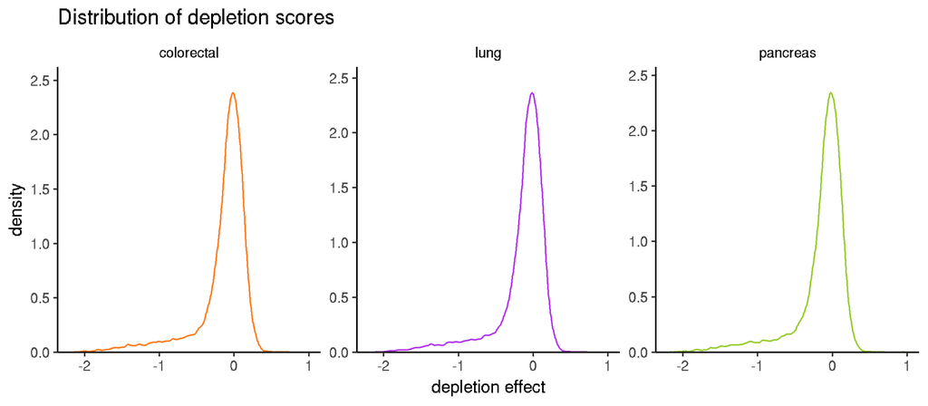

They are not normally distributed. Instead, most of the values lie near 0, indicating that most knock-out events had little impact on the viability of the cell lines (as expected). There is a tail to the left filled with the genes that did have an effect when knocked-out.

# 3 Linear model

(Analysis conducted in `subscripts/linear_model.R`.)

## 3.1 *KRAS* G13D vs *KRAS* G12 vs. WT and target gene mutation

### 3.1.1 The model

The first attempt at modeling the data used a standard linear model to estimate the depletion effect given the *KRAS* allele and mutation status of the target gene. The model had two covariates, *KRAS* allele and the mutational status of the target gene (binary). The alleles were grouped as *KRAS* codon 12, *KRAS* G13D, or WT. Only genes that caused a depletion to -0.5 or lower in at least one cell line were used.

Cell lines were not used if they had multiple *KRAS* mutations or a mutation in *NRAS* or *A/B/CRAF*.

### 3.1.2 Volcano plot of *KRAS* G12 - G13D estimate

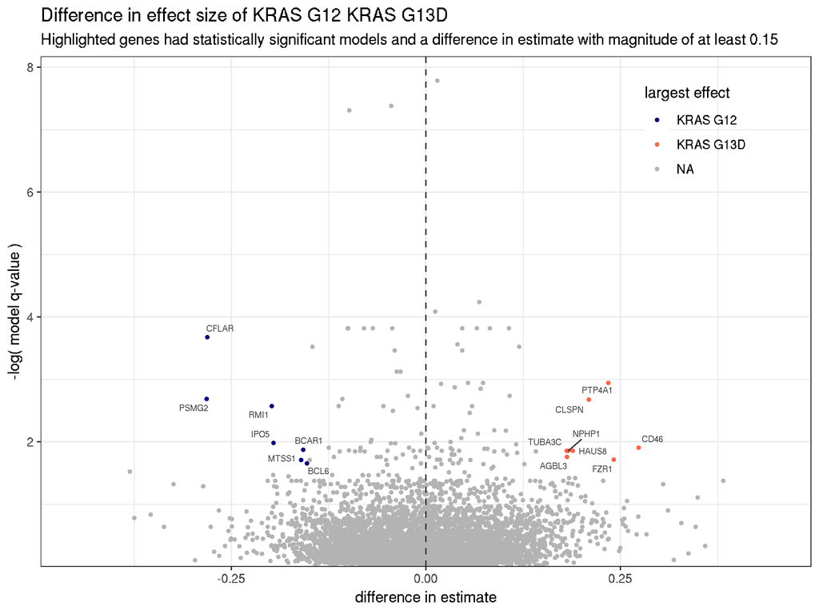

The genes with very low model q-values but little difference between *KRAS* G12 and G13D estimates (middle of the x-axis and high on the y-axis) were likely highly predicted by the WT covariate (i.e. the gene effect did not change much according to the *RAS* allele) or mutational status.

### 3.1.3 Genes with increased depletion with *KRAS* G13D

The plot shows target genes that had a significantly stronger depletion effect in *KRAS* G13D cell lines. These genes showed increased depletion in *KRAS* G13D cell lines, had a model q-value below 0.20, and a p-value for the G13D covariate below 0.05.

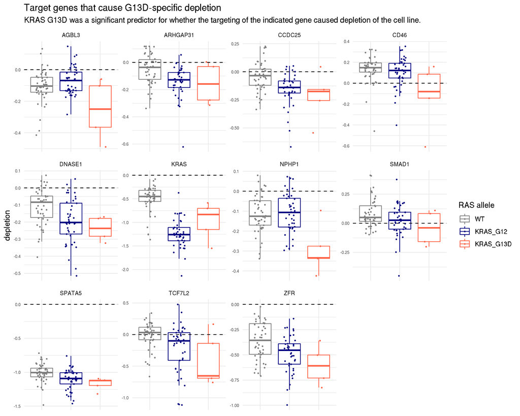

### 3.1.4 Genes with decreased depletion with *KRAS* G13D

On the other hand, the following plot shows target genes that had a significantly stronger *survival* effect (relative to the other alleles tested) in *KRAS* G13D cell lines. I use the term “survival” here due to a lack of a better option, but “reduced synthetic lethality” or “reduced depletion effect” may be more accurate.

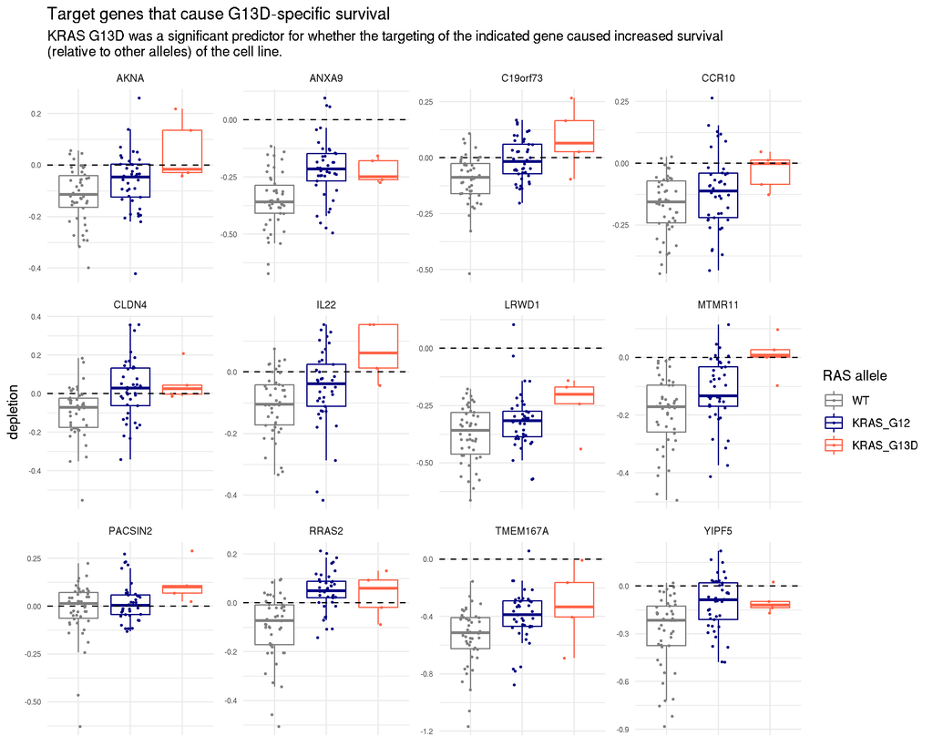

## 3.2 Only G12 and G13D

I have additionally fit the same model without WT samples, thus the intercept was the *KRAS* G12 effect and other covariates were *KRAS* G13D and mutational status of the target. Looking at the target genes that could be modeled and how their results compare to the previous version of the model (with WT), they do not capture any new effects. I believe including the WT as the intercept is a logical inclusion.

## 3.3 Including gene expression of the target gene

I ran the same model as before, including *KRAS* WT, G12, and G13D and whether the target gene was mutated or not, now including the RNA expression levels of the target gene in each cell line.

### 3.3.1 Volcano plot of *KRAS* G13D estimate

The following plot is a volcano with the *KRAS* G13D effect on the x-axis and log-transformed p-value of the *KRAS* G13D coefficient on the y-axis. The highlighted genes had an overall model q-value below 0.20, *KRAS* G13D p-value below 0.05, and a *KRAS* G13D estimate of magnitude greater than 0.20.

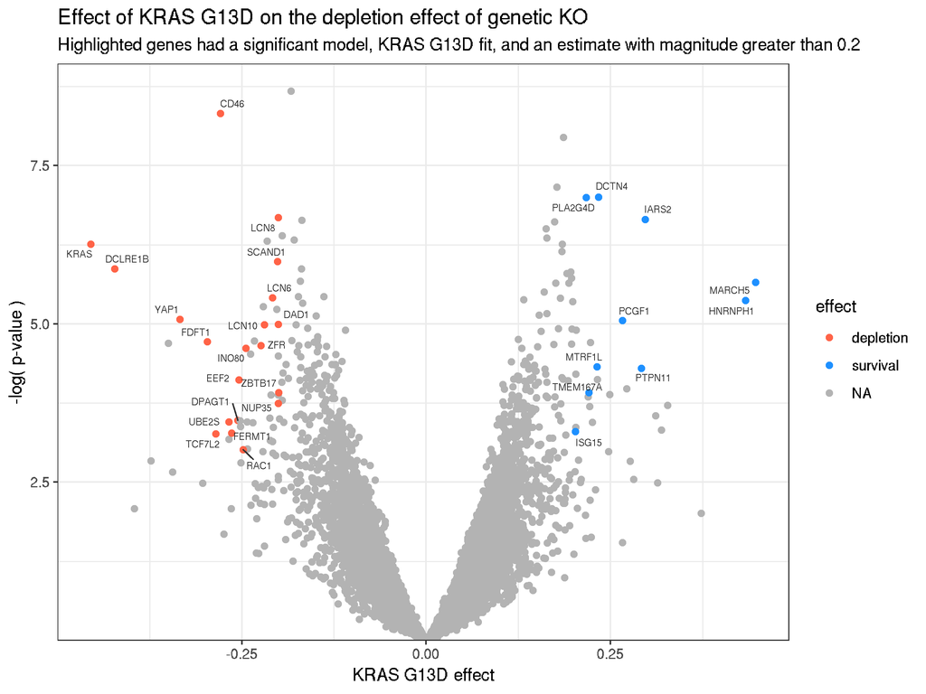

### 3.3.2 Volcano plot of *KRAS* G12 - G13D estimate

The volcano plot below shows the difference in the estimates for *KRAS* G12 and *KRAS* G13D and the log-transformed BH FDR-adjusted p-value (q-value) of the model. The labeled genes had a model q-value less than 0.20 and a difference in estimate of magnitude greater than 0.2. The points to the left (blue) had a stronger depletion effect in *KRAS* G12 mutants where the points to the right (red) had a stronger depletion effect in *KRAS* G13D.

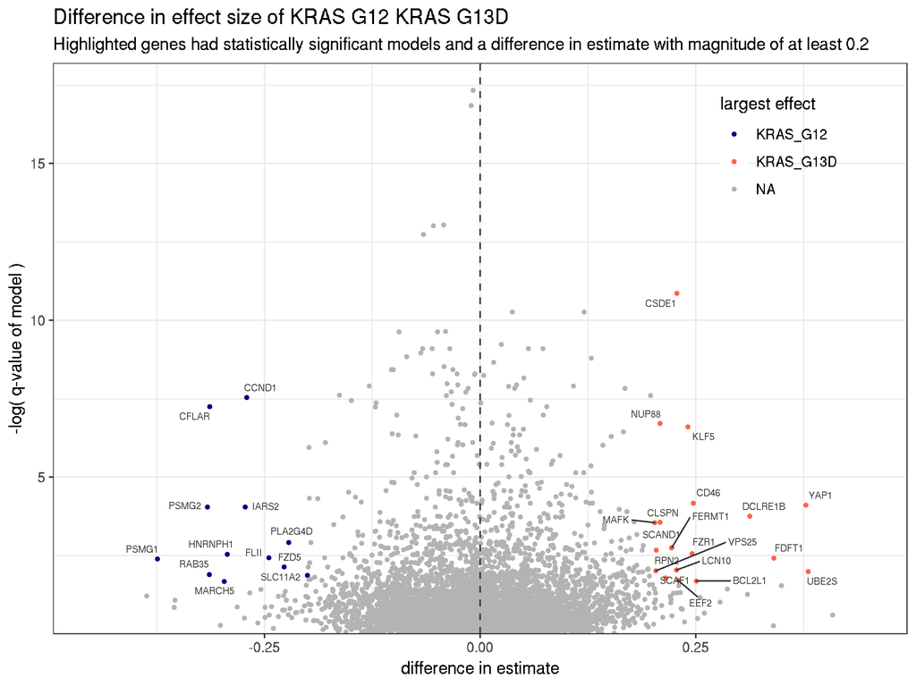

The plot below compares the coefficients fit to *KRAS* G12 (x-axis) and G13D (y-axis). Values that lie along the dashed line showed no difference in depletion effects between the two mutant *KRAS* groups. The highlighted genes had significant models (q_value < 0.20) and a difference in coefficients of 0.2 in magnitude.

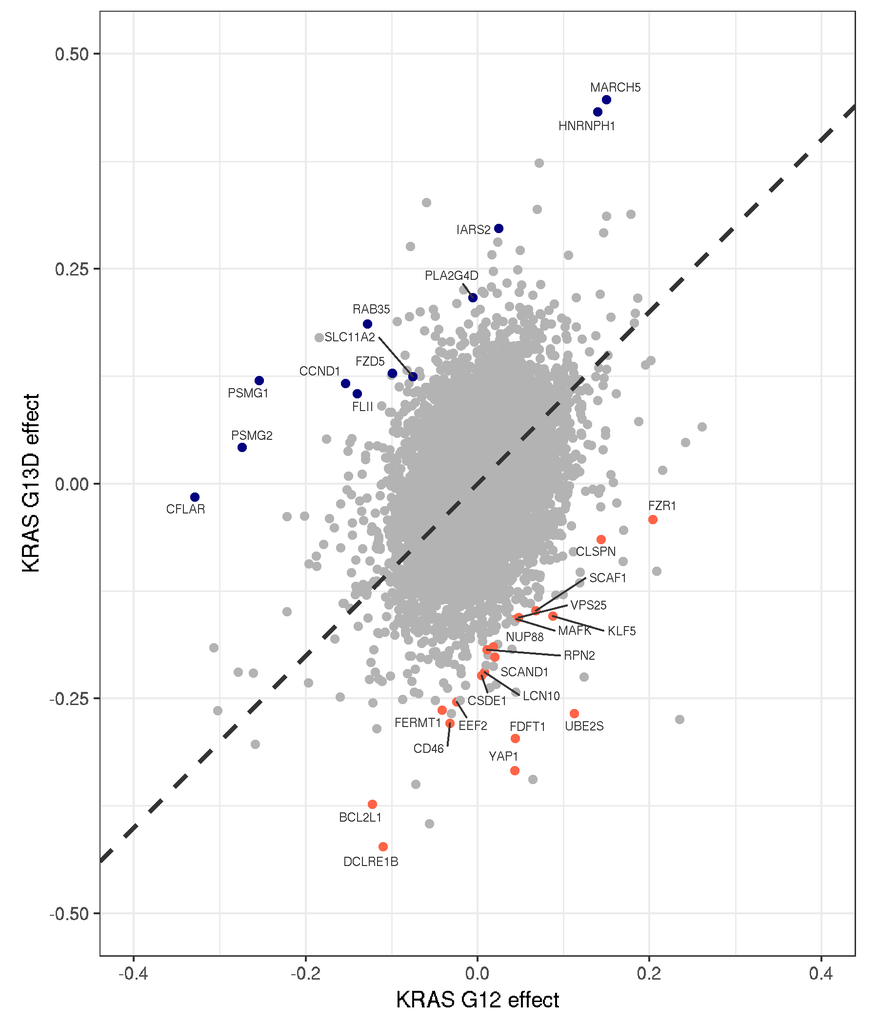

### 3.3.4 Genes with increased depletion with *KRAS* G13D

The plot shows target genes that had a significantly stronger depletion effect in *KRAS* G13D cell lines. These genes showed increased depletion in *KRAS* G13D cell lines, had a model q-value below 0.20, and a p-value for the G13D covariate below 0.05.

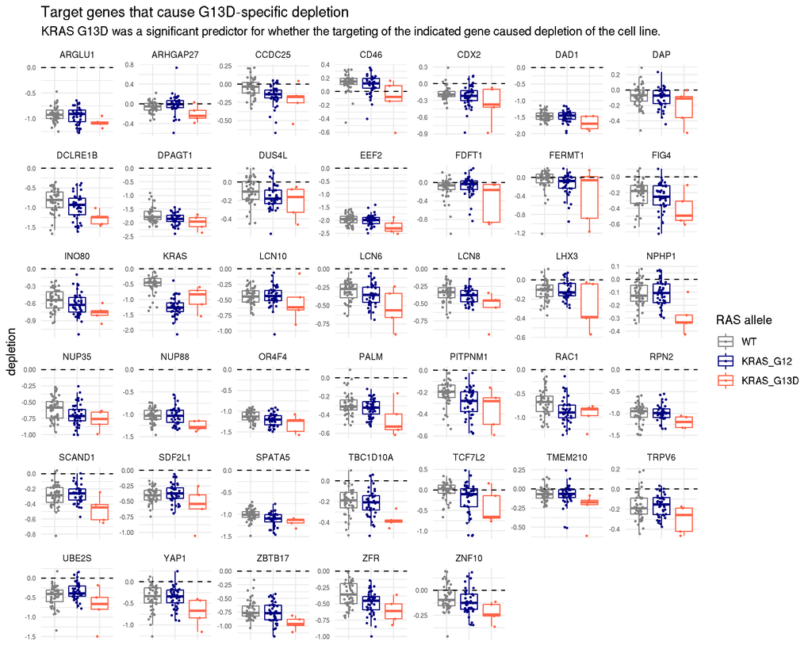

### 3.3.5 Genes with decreased depletion with *KRAS* G13D

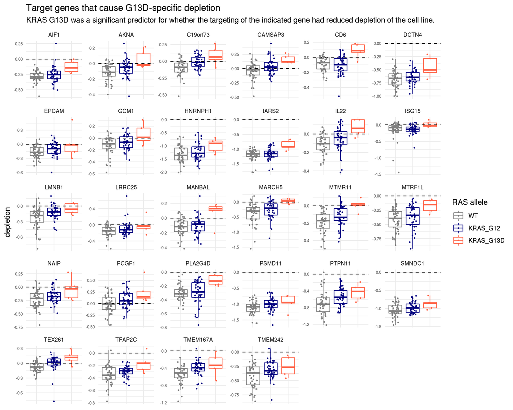

### 3.3.6 Effects of gene expression

The following plots show the trend of gene expression with depletion score for models found to have a significant coefficient and estimate (slope) of at least 0.15 in magnitude.

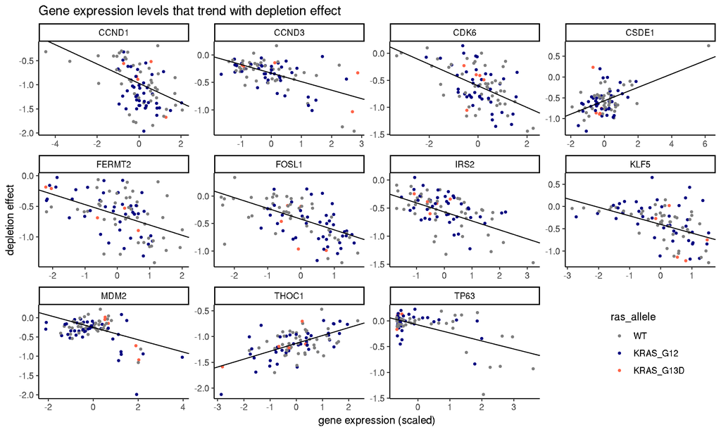

### 3.3.7 Effect of mutational status of the target gene

Inspecting the target genes that had statistically significant coefficients for the mutational status covariate (non-synonymous mutations only) revealed that many models were significant with only one or two cell lines with a mutation. The plot below shows the models with significant mutational status coefficients with an effect size of at least 0.15 in magnitude and at least four cell lines with a mutation in the gene.

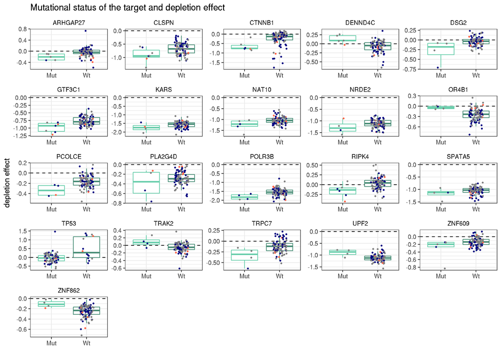

## 3.4 Conditional mutational status

From the previous observation that some models were fitting significant and relatively large coefficients to the mutational status covariate when only couple of cell lines had a mutation, I restricted the inclusion of this covariate to models of genes mutated in at least four cell lines.

The following plots have the same layout as in previous models, so are not specifically explained in each tab.

### 3.4.1 Volcano plot of *KRAS* G12 - G13D estimate

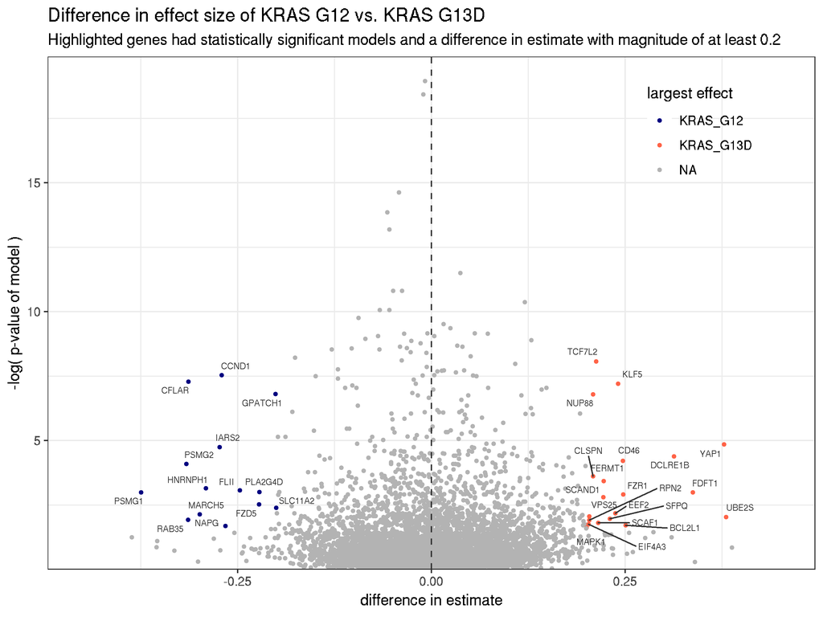

### 3.4.2 Comparing coefficients of *KRAS* G12 and G13D

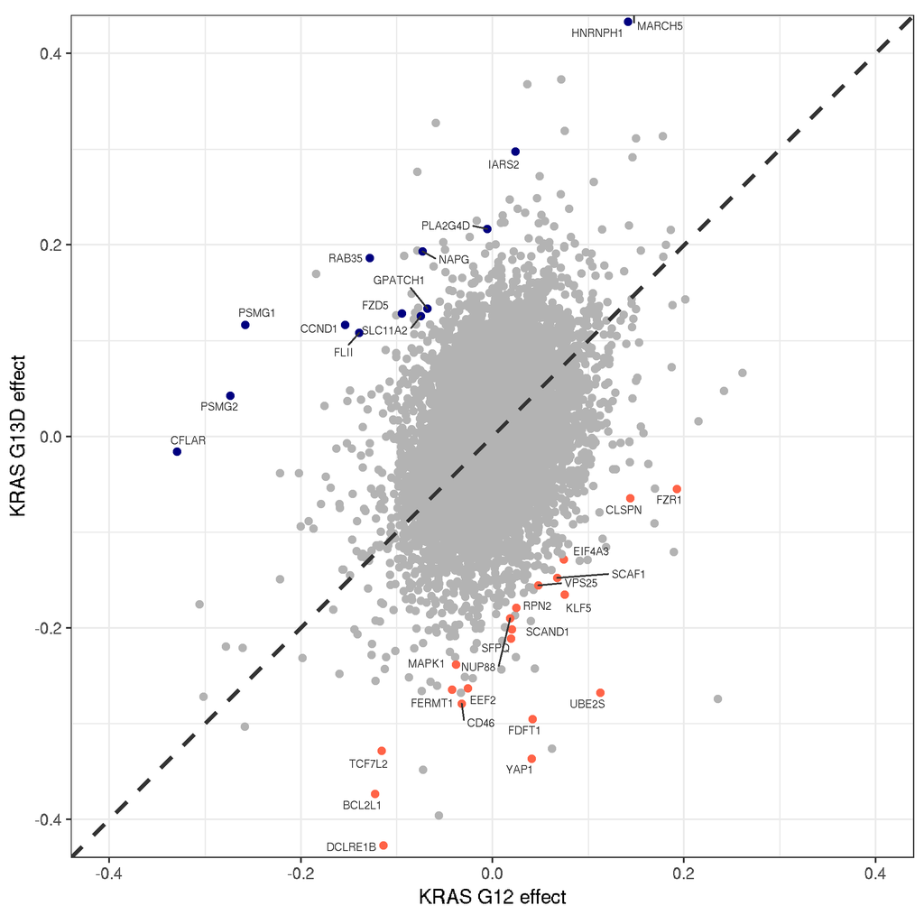

### 3.4.3 Genes with increased depletion with *KRAS* G13D

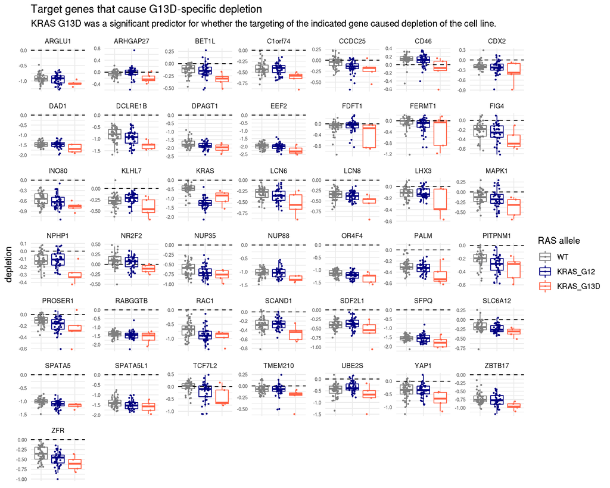

### 3.4.4 Genes with decreased depletion with *KRAS* G13D

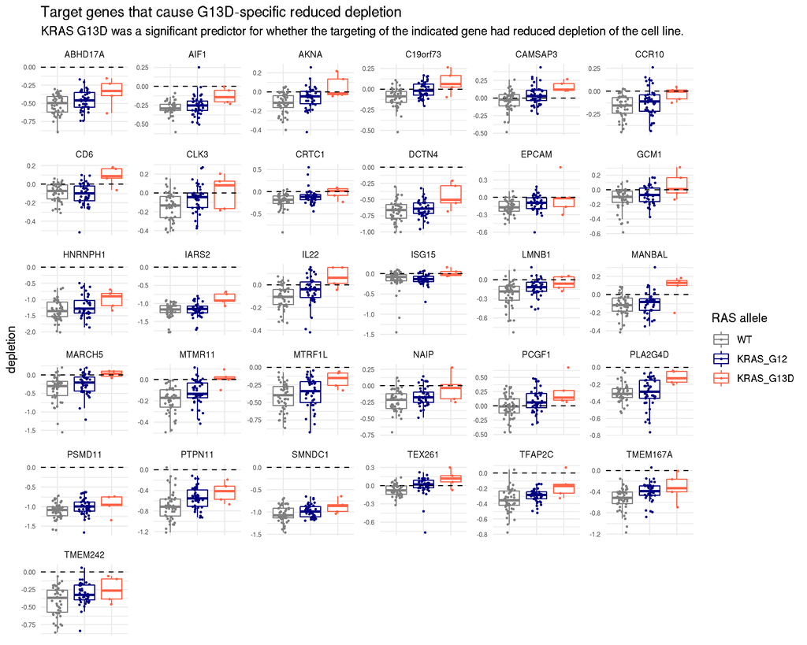

## 3.5 Only comparing *KRAS* G12D to G13D

Instead of including all codon 12 *KRAS* mutants in one group, the following model is the same as used in the previous section, though only using *KRAS* G12D. This may reduce variability of the codon 12 group if the various allele that constitute it are quite different.

### 3.5.1 Volcano plot of *KRAS* G12D - G13D estimate

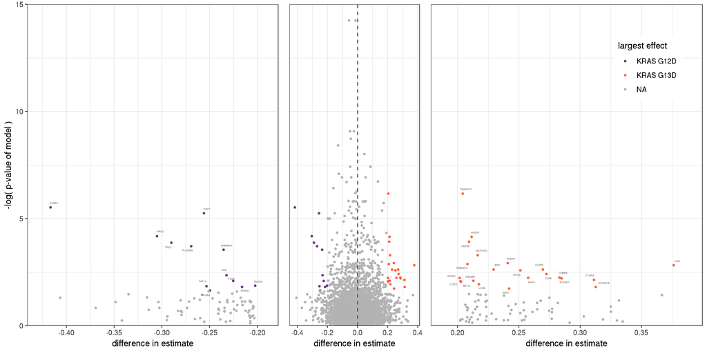

### 3.5.2 Comparing coefficients of *KRAS* G12 and G13D

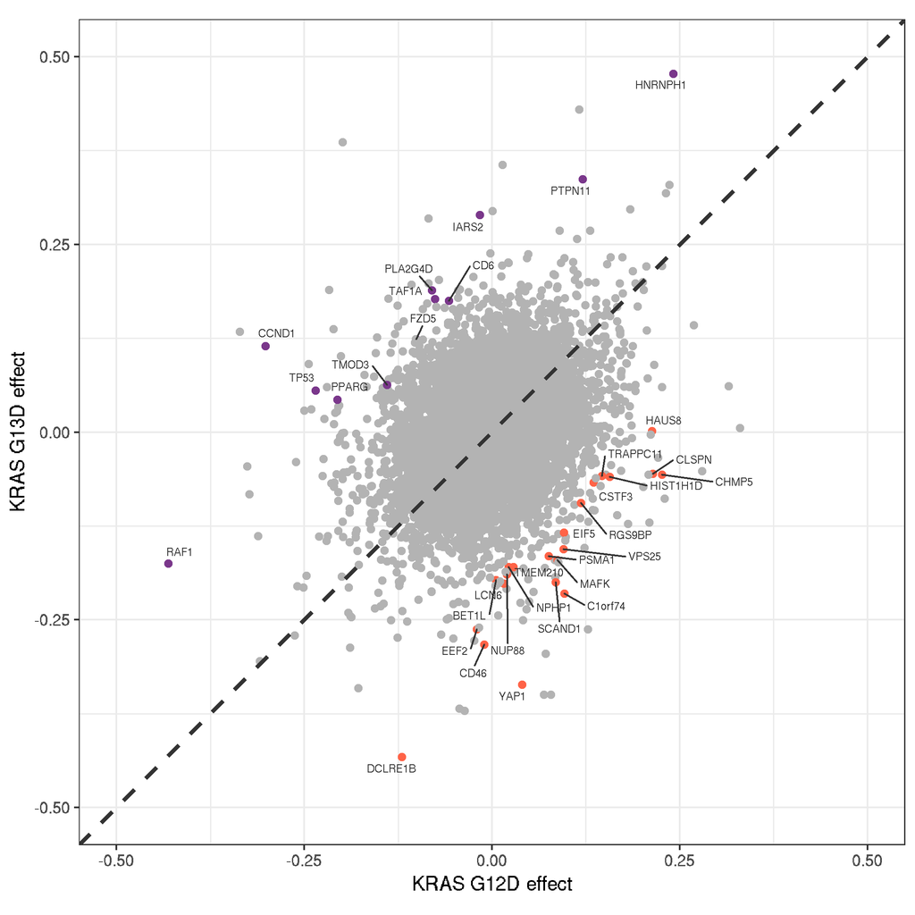

### 3.5.3 Genes with increased depletion with *KRAS* G13D

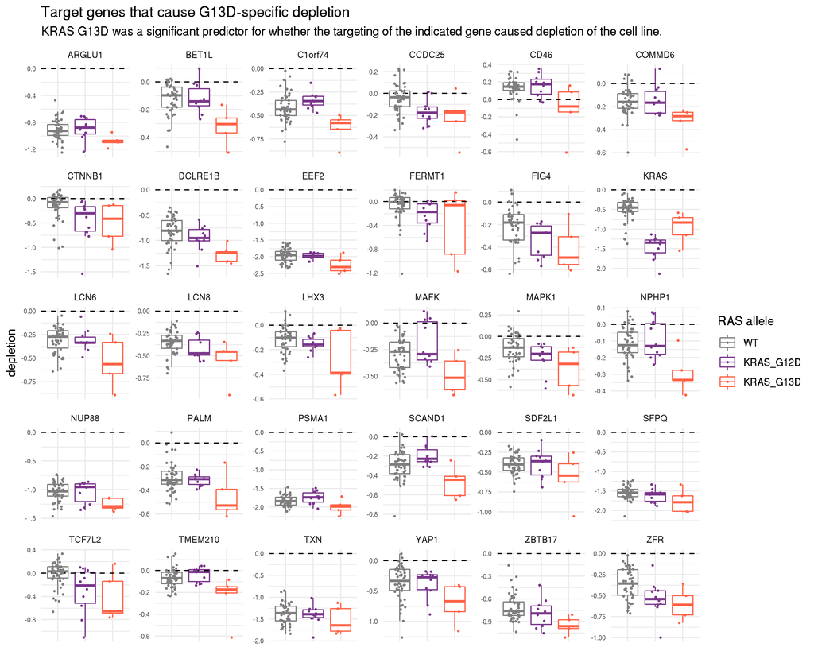

### 3.5.4 Genes with decreased depletion with *KRAS* G13D

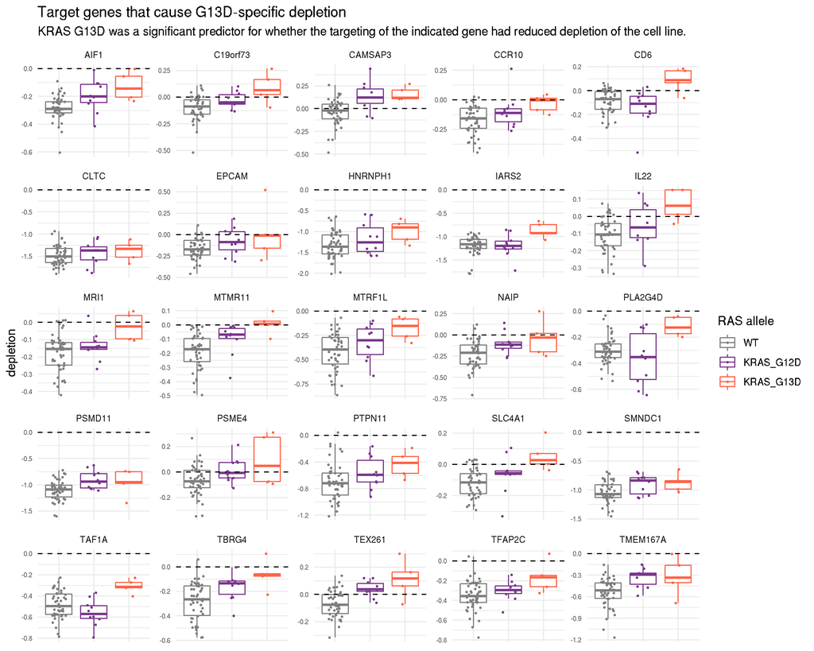

## 3.6 Additional Analysis of hits

### 3.6.1 Co-mutation in human tumors

I looked at the frequency of co-mutation of the genes identified by the linear model with *KRAS* G12, *KRAS* G13D, and WT in human tumor samples from COAD, LUAD, and PAAD. Below is a heatmap colored by co-mutation frequency. The numbers in the cells indicate the number of co-mutation events.

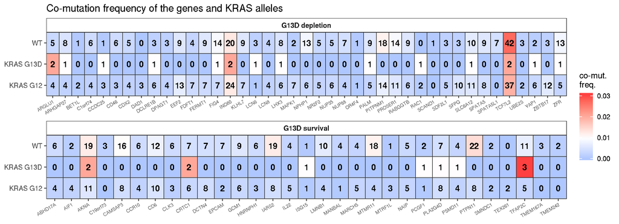

The following heatmap has the same information, however the fill color indicates the co-mutation frequency scaled from 0 to 1 for each gene individually. This gives an indication of the relative rates of co-mutation for each gene.

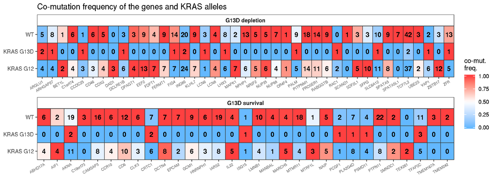

# 4 Predicting *KRAS* mutation using depletion effects

Instead of using the mutational status of *KRAS* to explain the depletion effect of each targeted gene in a separate model, I tried to predict the status of *KRAS* using all of the depletion scores in one model.

## 4.1 LASSO-regularized regression

I tried LASSO and Ridge for penalized regression and found that the strong effects of LASSO were preferable due the high dimensionality of the problem. I began by just using LASSO to predict whether a cell line would have WT or mutant *KRAS*. Below are the genes with non-zero effects (not including the effect of knocking-out *KRAS*).

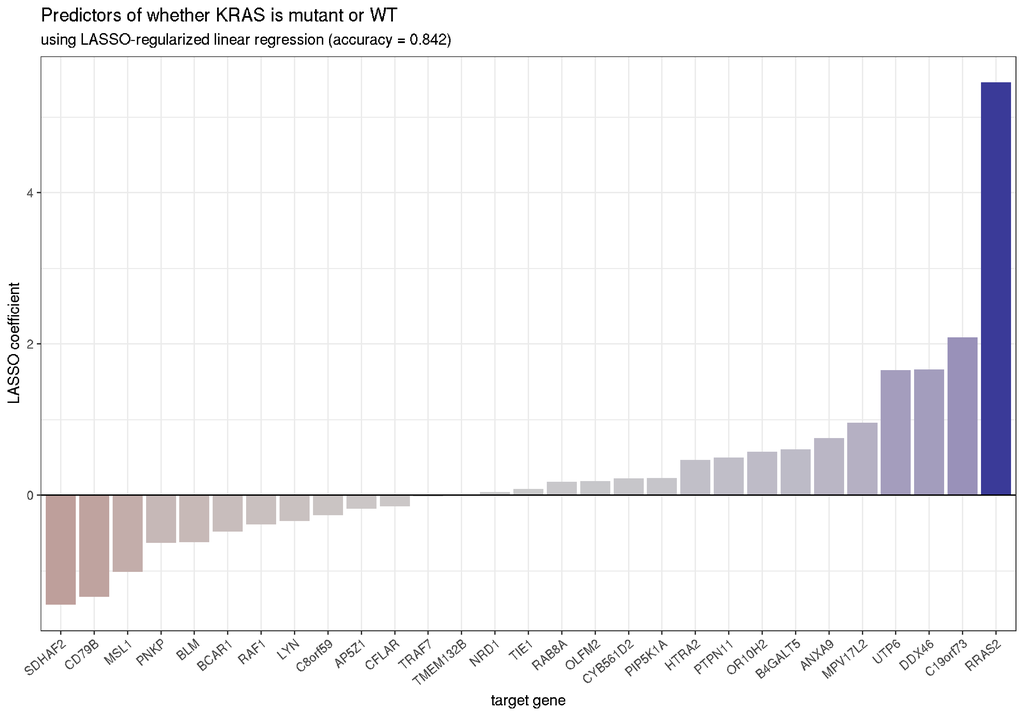

The following box-plots show the depletion effects in mutant and WT *KRAS* cell lines for the identified genes.

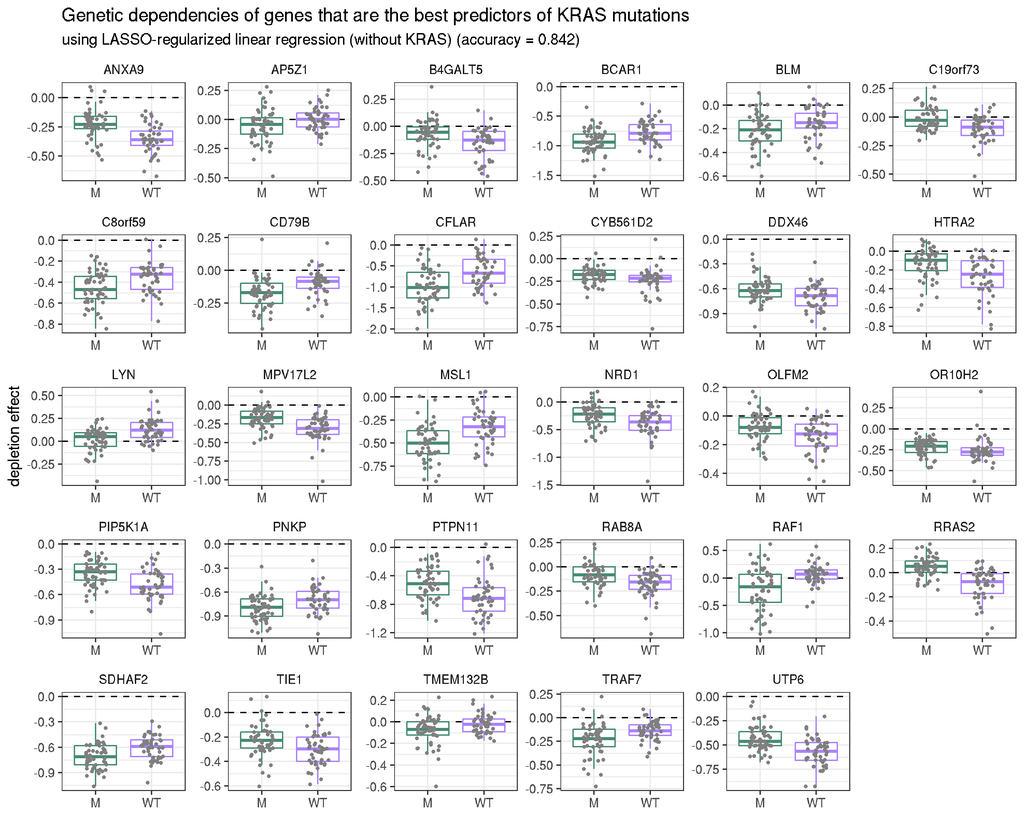

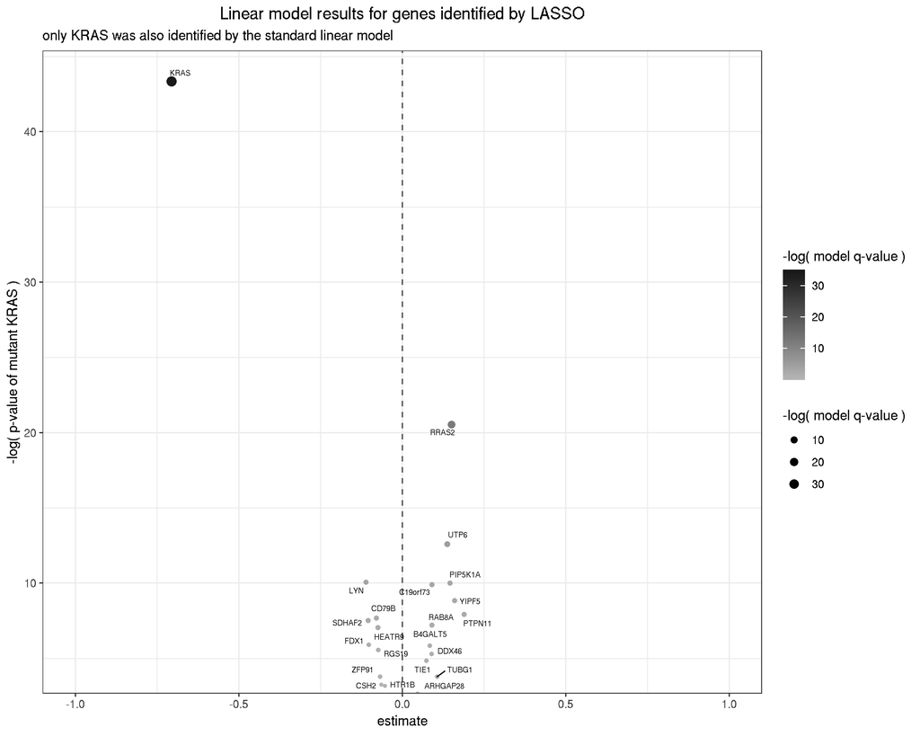

## 4.2 Random Forrest Classifier

I tried using a random forest classifier to classify whether KRAS was WT or mutated in a cell line based off of the depletion effects of all genes, but this had poor accuracy (around 50%).

I did not pursue this any further.

## 4.3 Conclusion

Using machine learning algorithms requires the split of the data into testing and training data sets. Due to the relatively low number of *KRAS* G13D samples, these methods are not applicable for an allele-specific analysis.

Still, the LASSO-regularized linear regression on *KRAS* mutational status was interesting and may have identified a few avenues of further exploration.

There is currently minimal code in the README, however, it will be added at the end from the scripts where the analysis was originally done. The end goal is for the README to be a fully reproducible document on its own.